# Microbial Compositional Analysis of Mid- and Late-lactation Dairy Samples Along a Processing Pipeline

Kailyn Hanke

2025-04-27

The goal of this document is to run an analysis of microbial composition of mid- and late-lactation dairy samples across a processing pipeline, similar to the analysis that I ran in 07_Composition. This is the third of three new analysis documents I will make (I have previously made 08_Seasonal_Biodiversity and 09_Ordination). See more info on my organizational layout under “Goals” in 08_Seasonal_Biodiversity.

Note that with this document I would really like to explore any potential compositional differences that are driving the separate clustering in my skimmed milk powder samples.

# Goals

1. Load in scaled/normalized phyloseq object.
2. Calculate the relative abundances of taxonomic groups at various levels: A. Phylum B. Genus C. ASV
3. Plot them, and narrow in on specific taxonomic group of interest
1. We will need the `scaled_physeq_season.RData`, which includes a rooted tree that we created in `analysis/09_Seasonal_Ordination/scaled_physeq_season.RData`.

## Outputs

1. Beautiful visualizations of microbial taxa and how they vary across dairy sample types (including mid- and late-lactation information.
2. Run some stats!

# Setup

## Timing of this script

```r
# What time did we start running this script?
start_time <- Sys.time()
```

## Set the seed

```r
set.seed(111111)
```

## Load Packages

```r
# Load in the packages
pacman::p_load(tidyverse, devtools, DT, phyloseq, patchwork, ggpubr, rstatix,
               install = FALSE)

# load colors
source("code/colors.R")
```

## 1. Load in Scaled Phyloseq object

The following phyloseq object contains microbial community composition data in a standardized format. In this case, we’ve already normalized the reads (scaled to 20090 per sample and including season data), which is essential for comparing relative abundances.

```r
load("data/09_Seasonal_Ordination/scaled_physeq_season.RData")

load("data/06_Ordination/scaled_physeq.RData")

load("data/09_Seasonal_Ordination/metadata_df_season.RData")

#Intuition check
min(sample_sums(scaled_physeq)) #19933
```

```
## [1] 19933
```

```r
#Note for some reason the scaled_phyloseq_season wasn't loading in! Will create scaled_physeq_season again until I fix the error
```

First I will mutate my metadata to include a new column season to define mid- and late-lactation.

```r
#To include seasons, need to update the sample_data in my phyloseq object

# Update the sample_data to include season
sample_data(scaled_physeq) <- sample_data(metadata_df_season)

# Save the updated phyloseq object
scaled_physeq_season <- scaled_physeq
```

# Taxonomic Analysis!

## A. Phylum

```r
phylum_df_season <-
  scaled_physeq_season %>%
  # Agglomerate all ASV counts within a phylum
  tax_glom(taxrank = "Phylum") %>%
  # Calculate the relative abundance!
  transform_sample_counts(function(x) {x/sum(x)}) %>%
  # Create a dataframe from phyloseq object
  psmelt() %>%
  #Filter out Phyla < 1 %
  #dplyr::filter(Abundance > 0.01) %>%
  #Fix the station order
  mutate(environment_material = fct_relevel(environment_material, c(
    "Bulk Tank Milk", "Collection Tanker Milk", "Whole Milk Silo", "Cream Silo", "Skimmed Milk Silo", "Skimmed Milk Powder")))

#What are the phylum abundances?
phylum_df_season %>%
  group_by(Phylum, season) %>%
  summarize(mean_PercAbund = round(mean(Abundance), digits = 4), .groups = "drop") %>%
  arrange(season, -mean_PercAbund) %>%
  datatable()
```

|  | Phylum | season | mean_PercAbund |
| --- | --- | --- | --- |
| 1 | Pseudomonadota | late-lactation | 0.3744 |
| 2 | Bacillota | late-lactation | 0.2959 |
| 3 | Bacteroidota | late-lactation | 0.161 |
| 4 | Actinomycetota | late-lactation | 0.1174 |
| 5 | Verrucomicrobiota | late-lactation | 0.0216 |
| 6 | Acidobacteriota | late-lactation | 0.007 |
| 7 | Planctomycetota | late-lactation | 0.0046 |
| 8 | Myxococcota | late-lactation | 0.0038 |
| 9 | Thermodesulfobacteriota | late-lactation | 0.0035 |
| 10 | Spirochaetota | late-lactation | 0.0033 |

[output cut: 98 more lines]

```r
top10_phyla_season <-
  phylum_df_season %>%
  group_by(season, Phylum) %>%
  # group by BOTH season and phylum
  summarize(mean_PercAbund = mean(Abundance), .groups = "drop") %>%
  # regroup by season
  group_by(season) %>%
  # take top 10 per season
  slice_max(order_by = mean_PercAbund, n = 10) %>%
  arrange(season, -mean_PercAbund)

#Identify top phyla in mid-lactation samples
top10_phyla_mid <-
  phylum_df_season %>%
  filter(season == "mid-lactation") %>%
  group_by(Phylum) %>%
  summarize(mean_PercAbund = mean(Abundance)) %>%
  arrange(-mean_PercAbund) %>%
  slice_head(n = 10) %>%
  pull(Phylum) #comment out to have mini df w/ abundances

#View
top10_phyla_mid
```

```
##  [1] "Bacillota"               "Pseudomonadota"
##  [3] "Bacteroidota"            "Actinomycetota"
##  [5] "Deinococcota"            "Verrucomicrobiota"
##  [7] "Spirochaetota"           "Thermodesulfobacteriota"
##  [9] "Acidobacteriota"         "Planctomycetota"
```

```r
#Identify top phyla in late-lactation samples
top10_phyla_late <-
  phylum_df_season %>%
  filter(season == "late-lactation") %>%
  group_by(Phylum) %>%
  summarize(mean_PercAbund = mean(Abundance)) %>%
  arrange(-mean_PercAbund) %>%
  slice_head(n = 10) %>%
  pull(Phylum) #comment out to have mini df w/ abundances


#View
top10_phyla_late
```

```
##  [1] "Pseudomonadota"          "Bacillota"
##  [3] "Bacteroidota"            "Actinomycetota"
##  [5] "Verrucomicrobiota"       "Acidobacteriota"
##  [7] "Planctomycetota"         "Myxococcota"
##  [9] "Thermodesulfobacteriota" "Spirochaetota"
```

The first bit of analysis I did was identify the top 10 phyla in my mid-lactation samples and my late lactation samples.

When looking at the top ten phyla for each season, they share 9/10 top ten phyla. In the mid-lactation samples, Deinococcota makes the top ten, while in the late-lactation samples, Myxococcota makes the cut but Deinococcota doesn’t.

So, to further explore these results, in the following graph I will plot the 9 shared top 10 phyla, as well as both Deinococcota and Myxococcota (total of 11 phyla). I will also have a bar for each season within each phyla plot.

## Stacked Bar plots

### Mid-lactation

```r
#Intuition check all phyla in top ten for mid-lactation in phylum_colors (in my previous composition doc they were not and it caused me a bunch of avoidable issues)

top10_phyla_mid %in% names(phylum_colors)
```

```
##  [1] TRUE TRUE TRUE TRUE TRUE TRUE TRUE TRUE TRUE TRUE
```

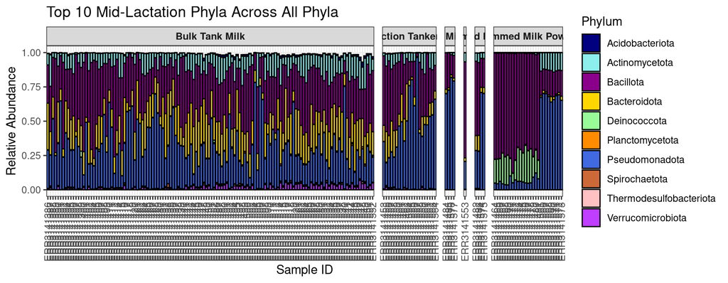

```r
#actual plot (by sample)
stacked_plot_mid <- phylum_df_season %>%
  filter(Phylum %in% top10_phyla_mid) %>%
  ggplot(aes(x = Sample, y = Abundance, fill = Phylum)) +
  geom_bar(stat = "identity", color = "black") +
  scale_y_continuous(limits = c(0, 1)) +
  facet_grid(. ~ environment_material, scales = "free_x", space = "free_x") +
  labs(title = "Top 10 Mid-Lactation Phyla Across All Phyla",
       y = "Relative Abundance", x = "Sample ID") +
  scale_fill_manual(values = phylum_colors) +
  theme_bw() +
  theme(axis.text.x = element_text(angle = 90, vjust = 0.5, hjust = 1),
        strip.text = element_text(face = "bold"),
        panel.spacing.x = unit(0.5, "lines"))

stacked_plot_mid
```

### Late-lactation

```r
#Intuition check all phyla in top ten for late-lactation in phylum_colors (in my previous composition doc they were not and it caused me a bunch of avoidable issues)

top10_phyla_late %in% names(phylum_colors)
```

```
##  [1] TRUE TRUE TRUE TRUE TRUE TRUE TRUE TRUE TRUE TRUE
```

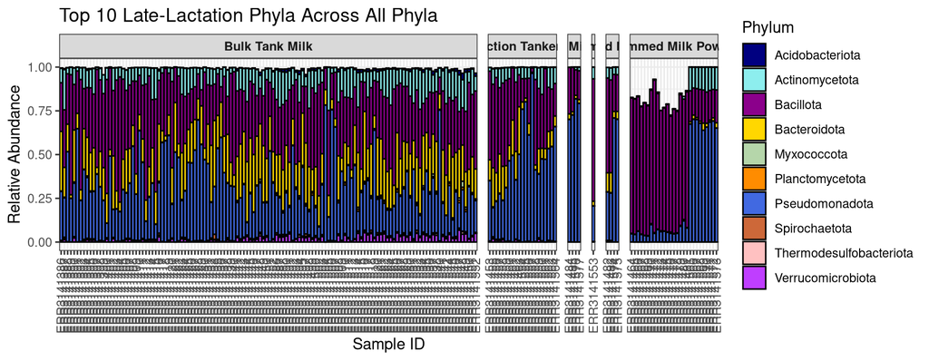

```r
#actual plot (by sample)
stacked_plot_late <- phylum_df_season %>%
  filter(Phylum %in% top10_phyla_late) %>%
  ggplot(aes(x = Sample, y = Abundance, fill = Phylum)) +
  geom_bar(stat = "identity", color = "black") +
  scale_y_continuous(limits = c(0, 1)) +
  facet_grid(. ~ environment_material, scales = "free_x", space = "free_x") +
  labs(title = "Top 10 Late-Lactation Phyla Across All Phyla",
       y = "Relative Abundance", x = "Sample ID") +
  scale_fill_manual(values = phylum_colors) +
  theme_bw() +
  theme(axis.text.x = element_text(angle = 90, vjust = 0.5, hjust = 1),
        strip.text = element_text(face = "bold"),
        panel.spacing.x = unit(0.5, "lines"))

stacked_plot_late
```

See how in Skimmed Milk powder within `stacked_plot_late` there is a group of samples where the top ten phyla do not cover close to 100% of the abundance. I will now plot late-lactation phyla without filtering top ten to see which phyla (if there is only one) will fill that gap!

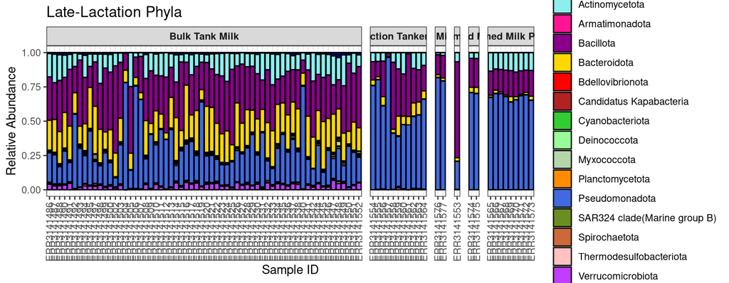

```r
stacked_plot_late_full <- phylum_df_season %>%
  filter(season == "late-lactation" & !is.na(Abundance)) %>%
  ggplot(aes(x = Sample, y = Abundance, fill = Phylum)) +
  geom_bar(stat = "identity", color = "black") +
  scale_y_continuous(limits = c(0, 1)) +
  facet_grid(. ~ environment_material, scales = "free_x", space = "free_x") +
  labs(title = "Late-Lactation Phyla",
       y = "Relative Abundance", x = "Sample ID") +
  scale_fill_manual(values = phylum_colors) +
  theme_bw() +
  theme(axis.text.x = element_text(angle = 90, vjust = 0.5, hjust = 1),
        strip.text = element_text(face = "bold"),
        panel.spacing.x = unit(0.5, "lines"))
stacked_plot_late_full
```

WOAH! I plotted this and it helped me discover in my two previous plots I was plotting ALL of the samples, just the first plot I was jst showing the ten most abundant phyla in mid-lactation across all samples and then the ten most abundant late-lactation phyla in all samples! Wow, I don’t know if I would have caught this otherwise!

I am now going to make two plots with only the mid-lactation samples (most abundant mid-lactation phyla) and only the late-lactation samples (most abundant late-lactation phyla).

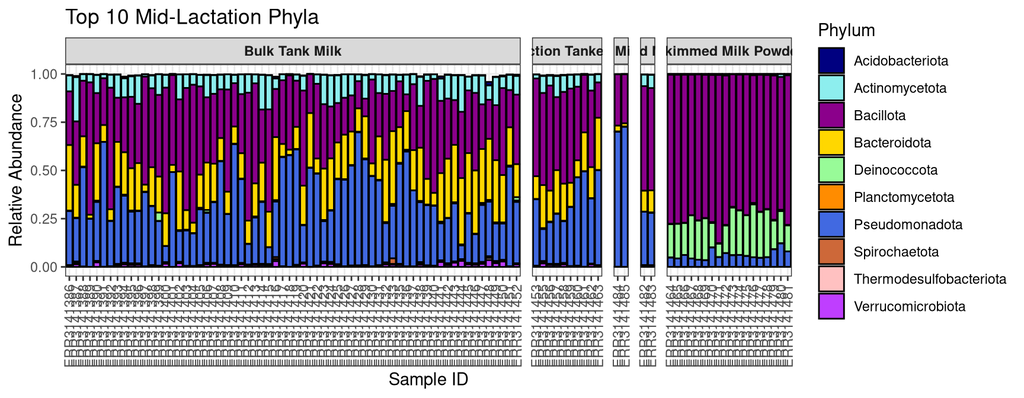

```r
stacked_plot_mid_onlyml <- phylum_df_season %>%
  filter(season == "mid-lactation" & Phylum %in% top10_phyla_mid) %>%
  ggplot(aes(x = Sample, y = Abundance, fill = Phylum)) +
  geom_bar(stat = "identity", color = "black") +
  scale_y_continuous(limits = c(0, 1)) +
  facet_grid(. ~ environment_material, scales = "free_x", space = "free_x") +
  labs(title = "Top 10 Mid-Lactation Phyla",
       y = "Relative Abundance", x = "Sample ID") +
  scale_fill_manual(values = phylum_colors) +
  theme_bw() +
  theme(axis.text.x = element_text(angle = 90, vjust = 0.5, hjust = 1),
        strip.text = element_text(face = "bold"),
        panel.spacing.x = unit(0.5, "lines"))

stacked_plot_mid_onlyml
```

Now that looks a little better!

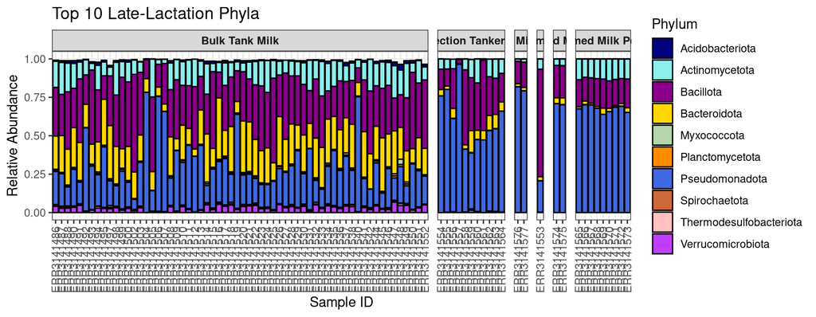

```r
stacked_plot_late_onlyll <- phylum_df_season %>%
  filter(season == "late-lactation" & Phylum %in% top10_phyla_late) %>%
  ggplot(aes(x = Sample, y = Abundance, fill = Phylum)) +
  geom_bar(stat = "identity", color = "black") +
  scale_y_continuous(limits = c(0, 1)) +
  facet_grid(. ~ environment_material, scales = "free_x", space = "free_x") +
  labs(title = "Top 10 Late-Lactation Phyla",
       y = "Relative Abundance", x = "Sample ID") +
  scale_fill_manual(values = phylum_colors) +
  theme_bw() +
  theme(axis.text.x = element_text(angle = 90, vjust = 0.5, hjust = 1),
        strip.text = element_text(face = "bold"),
        panel.spacing.x = unit(0.5, "lines"))

stacked_plot_late_onlyll
```

Now plot them together!

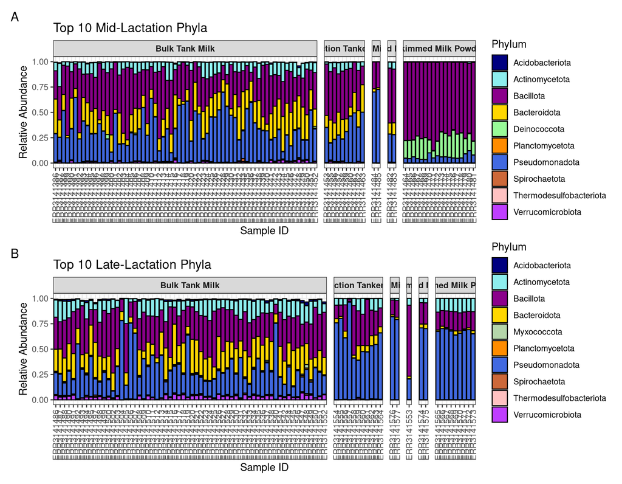

```r
stacked_plot_mid_onlyml +
stacked_plot_late_onlyll +
  plot_layout(ncol = 1, guides = "collect") +
  plot_annotation(tag_levels = "A")
```

Woah - this stacked bar chart of the top ten phyla by season really just gave me a first look into the different composition between the mid- and late-lactation samples, even at the level of phylum!! Here we can see that in the mid-lactation skim milk powder samples there is a sudden increase in the phylum Deinococcota. Meanwhile, in the late-lactation samples Pseudomonadota remains dominant.

Really intrigued by these results and wanted to explore this further. From my experience working in the Wiedmann Lab I know a bit about spoilage/dairy associated bacteria, and that Deinococcota has thermophilic genera that can be found in various dairy processing environments. I really want to dig into this increase in Deinococcota that we are seeing in mid-lactation samples. Because of this I generated a specific hypothesis I wanted to investigate:

Hypothesis: Mid-lactation skim milk powder will be enriched with thermophilic genera.

## Faceted Bar plot

Before I focus in on certain phyla/genera/ASVs, I would like to make a faceted bar plot with the top 10 phyla of both mid-lactation and late-lactation samples.

So in this graph I will plot the 9 shared top 10 phyla, and then both Deinococcota and Myxococcota (total of 11 phyla). I will also have a bar for each season within each phyla plot.

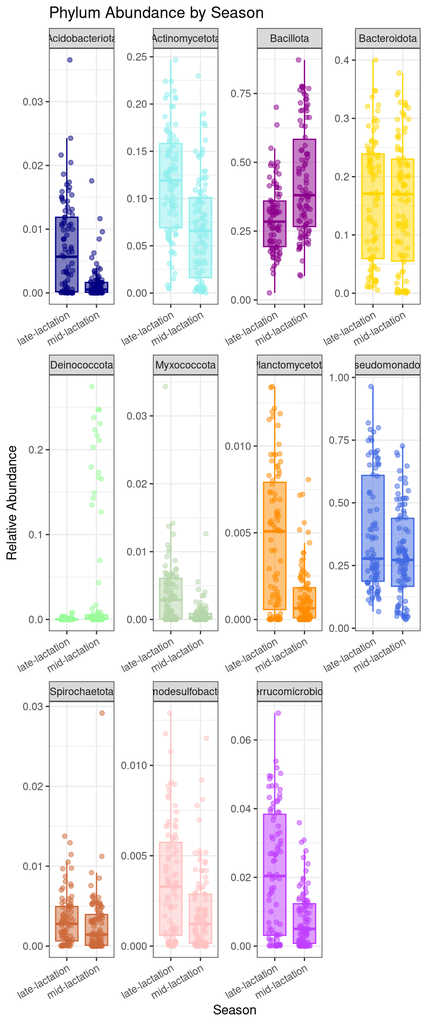

```r
phylum_df_season %>%
  filter(Phylum %in% c(
    "Bacillota", "Pseudomonadota", "Bacteroidota", "Actinomycetota", "Verrucomicrobiota", "Spirochaetota", "Thermodesulfobacteriota",
    "Acidobacteriota", "Planctomycetota", "Deinococcota", "Myxococcota"
  )) %>%
  ggplot(aes(x = season, y = Abundance, fill = Phylum, color = Phylum)) +
  facet_wrap(~Phylum, scales = "free", nrow = 3) +
  geom_jitter(width = 0.2, alpha = 0.5) +
  geom_boxplot(outlier.shape = NA, alpha = 0.5) +
  scale_fill_manual(values = phylum_colors) +
  scale_color_manual(values = phylum_colors) +
  theme_bw() +
  theme(
    legend.position = "none",
    axis.text.x = element_text(angle = 30, hjust = 1, vjust = 1)
  ) +
  labs(x = "Season", y = "Relative Abundance", title = "Phylum Abundance by Season")
```

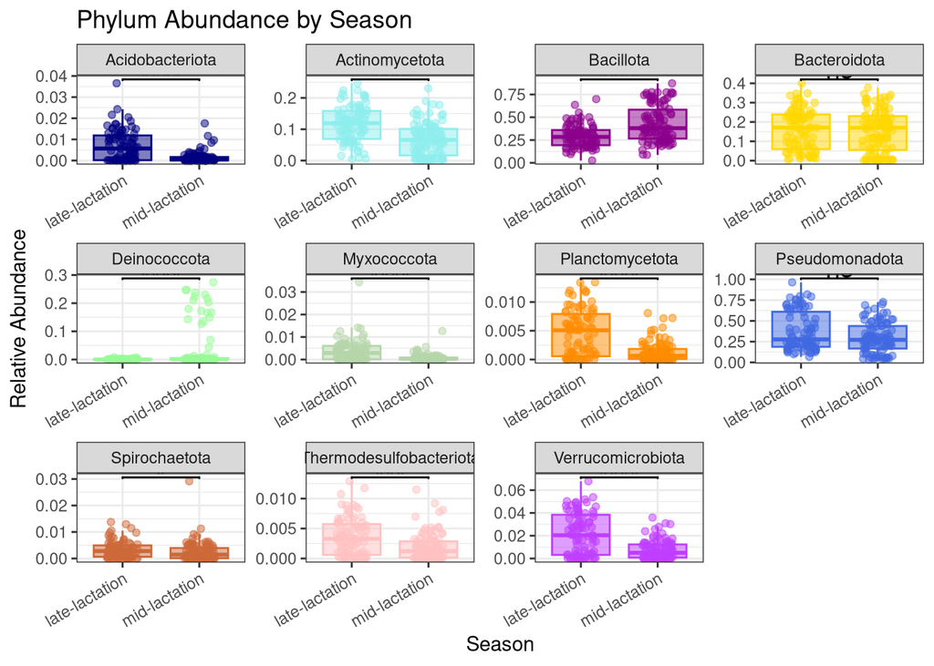

```r
# Do Wilcoxon test for each Phylum
wilcox_results <- phylum_df_season %>%
  filter(Phylum %in% c(
    "Bacillota", "Pseudomonadota", "Bacteroidota", "Actinomycetota", "Verrucomicrobiota", "Spirochaetota", "Thermodesulfobacteriota",
    "Acidobacteriota", "Planctomycetota", "Deinococcota", "Myxococcota"
  )) %>%
  group_by(Phylum) %>%
  wilcox_test(Abundance ~ season) %>%
  adjust_pvalue(method = "fdr") %>%  # Optional: adjust for multiple testing (FDR)
  add_significance("p.adj")


#fix sig plot

# Calculate the maximum Abundance for each Phylum
phylum_max <- phylum_df_season %>%
  group_by(Phylum) %>%
  summarise(max_abundance = max(Abundance, na.rm = TRUE)) %>%
  mutate(y.position = 1.05 * max_abundance)  # Add 5% extra space


# Assuming wilcox_results has a 'Phylum' column
wilcox_results2 <- wilcox_results %>%
  left_join(phylum_max, by = "Phylum")

# Plot
phylum_df_season %>%
  filter(Phylum %in% c(
    "Bacillota", "Pseudomonadota", "Bacteroidota", "Actinomycetota", "Verrucomicrobiota", "Spirochaetota", "Thermodesulfobacteriota",
    "Acidobacteriota", "Planctomycetota", "Deinococcota", "Myxococcota"
  )) %>%
  ggplot(aes(x = season, y = Abundance, fill = Phylum, color = Phylum)) +
  facet_wrap(~Phylum, scales = "free", nrow = 3) +
  geom_jitter(width = 0.2, alpha = 0.5) +
  geom_boxplot(outlier.shape = NA, alpha = 0.5) +
  scale_fill_manual(values = phylum_colors) +
  scale_color_manual(values = phylum_colors) +
  theme_bw() +
  theme(
    legend.position = "none",
    axis.text.x = element_text(angle = 30, hjust = 1, vjust = 1)
  ) +
  labs(x = "Season", y = "Relative Abundance", title = "Phylum Abundance by Season") +
  stat_pvalue_manual(
  wilcox_results2,
  label = "p.adj.signif",
  y.position = "y.position",   # <-- dynamic y-positions!
  bracket.size = 0.5,
  tip.length = 0.01,
  size = 5
)
```

### Deinococcota

Now it’s time to get into the good stuff!! Here I am going to plot the abundance of Deinococcota across each sample type, splitting up the samples by season.

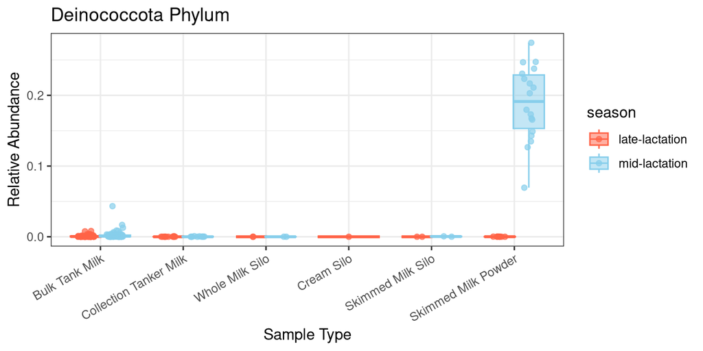

```r
deinococcota_phylum <-
  phylum_df_season %>%
  filter(Phylum == "Deinococcota") %>%
  ggplot(aes(x = environment_material, y = Abundance,
             fill = season, color = season)) +
  geom_boxplot(position = position_dodge(width = 0.7), alpha = 0.5, outlier.shape = NA) +
  geom_jitter(position = position_jitterdodge(jitter.width = 0.2, dodge.width = 0.7), alpha = 0.7) +
  theme_bw() +
  labs(title = "Deinococcota Phylum", x = "Sample Type", y = "Relative Abundance") +
  scale_color_manual(values = c("mid-lactation" = "skyblue", "late-lactation" = "tomato")) +
  scale_fill_manual(values = c("mid-lactation" = "skyblue", "late-lactation" = "tomato")) +
  theme(
    axis.text.x = element_text(angle = 30, hjust = 1, vjust = 1),
    legend.position = "right"
  )

deinococcota_phylum
```

WOW! We can very clearly see an increase in relative abundance (although did not run stats to prove significance) of Deinococcota in the mid-lactation samples but NOT the late-lactation samples. **This also explains the bimodal distribution we were seeing with Deinococcota originally when we weren’t splitting up the data by season.** This is really neat and I plan to continue with this analysis at the level of genus and ASV. I

But first, I want to look at a few different phyla…

### Myxococcota

Now, just for curiosity I am going to plot the phyla: Myxococcota, Bacillota, Bacteroidota and Pseudomonadota. Not to answer any specific hypothesis, but just to see if there’s anything interesting and help contribute to answering my main scientific question: How does microbial diversity change throughout the skim milk powder manufacturing process?

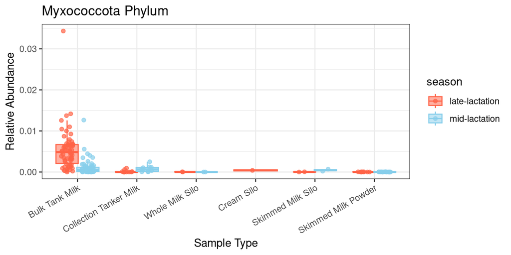

```r
myxococcota_phylum <-
  phylum_df_season %>%
  filter(Phylum == "Myxococcota") %>%
  ggplot(aes(x = environment_material, y = Abundance,
             fill = season, color = season)) +
  geom_boxplot(position = position_dodge(width = 0.7), alpha = 0.5, outlier.shape = NA) +
  geom_jitter(position = position_jitterdodge(jitter.width = 0.2, dodge.width = 0.7), alpha = 0.7) +
  theme_bw() +
  labs(title = "Myxococcota Phylum", x = "Sample Type", y = "Relative Abundance") +
  scale_color_manual(values = c("mid-lactation" = "skyblue", "late-lactation" = "tomato")) +
  scale_fill_manual(values = c("mid-lactation" = "skyblue", "late-lactation" = "tomato")) +
  theme(
    axis.text.x = element_text(angle = 30, hjust = 1, vjust = 1),
    legend.position = "right"
  )

myxococcota_phylum
```

Without testing for significance it is hard to draw conclusions from this myxococcota graph. In general it looks like the relative abundance is highest in late-lactation bulk tank milk samples.

### Bacillota

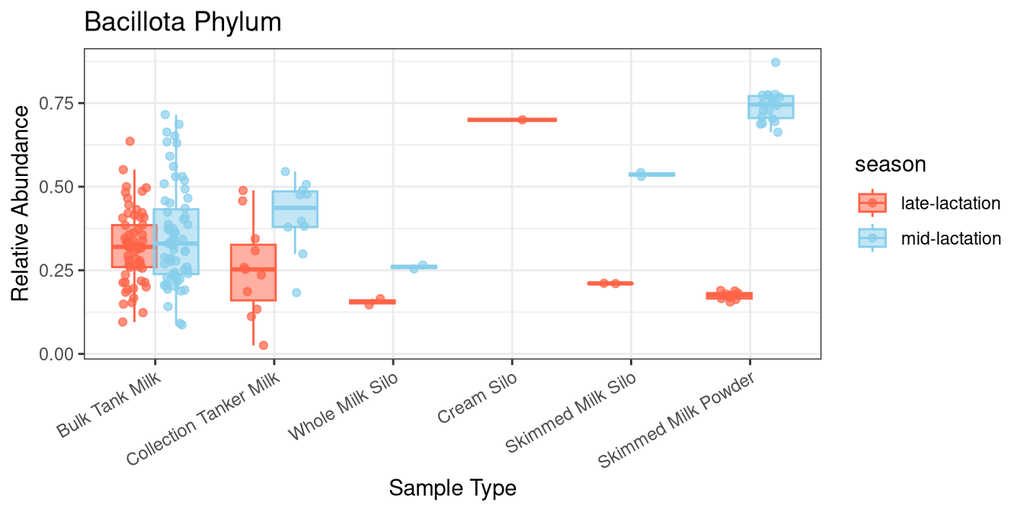

```r
bacillota_phylum <-
  phylum_df_season %>%
  filter(Phylum == "Bacillota") %>%
  ggplot(aes(x = environment_material, y = Abundance,
             fill = season, color = season)) +
  geom_boxplot(position = position_dodge(width = 0.7), alpha = 0.5, outlier.shape = NA) +
  geom_jitter(position = position_jitterdodge(jitter.width = 0.2, dodge.width = 0.7), alpha = 0.7) +
  theme_bw() +
  labs(title = "Bacillota Phylum", x = "Sample Type", y = "Relative Abundance") +
  scale_color_manual(values = c("mid-lactation" = "skyblue", "late-lactation" = "tomato")) +
  scale_fill_manual(values = c("mid-lactation" = "skyblue", "late-lactation" = "tomato")) +
  theme(
    axis.text.x = element_text(angle = 30, hjust = 1, vjust = 1),
    legend.position = "right"
  )

bacillota_phylum
```

Look at the difference in Skim Milk Powder samples!! Interesting!

This phylum also accounts for a huge proportion of overall relative abundance!

### Bacteroidota

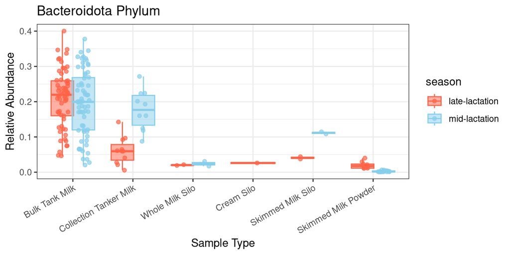

```r
bacteroidota_phylum <-
  phylum_df_season %>%
  filter(Phylum == "Bacteroidota") %>%
  ggplot(aes(x = environment_material, y = Abundance,
             fill = season, color = season)) +
  geom_boxplot(position = position_dodge(width = 0.7), alpha = 0.5, outlier.shape = NA) +
  geom_jitter(position = position_jitterdodge(jitter.width = 0.2, dodge.width = 0.7), alpha = 0.7) +
  theme_bw() +
  labs(title = "Bacteroidota Phylum", x = "Sample Type", y = "Relative Abundance") +
  scale_color_manual(values = c("mid-lactation" = "skyblue", "late-lactation" = "tomato")) +
  scale_fill_manual(values = c("mid-lactation" = "skyblue", "late-lactation" = "tomato")) +
  theme(
    axis.text.x = element_text(angle = 30, hjust = 1, vjust = 1),
    legend.position = "right"
  )

bacteroidota_phylum
```

### Pseudomonadota

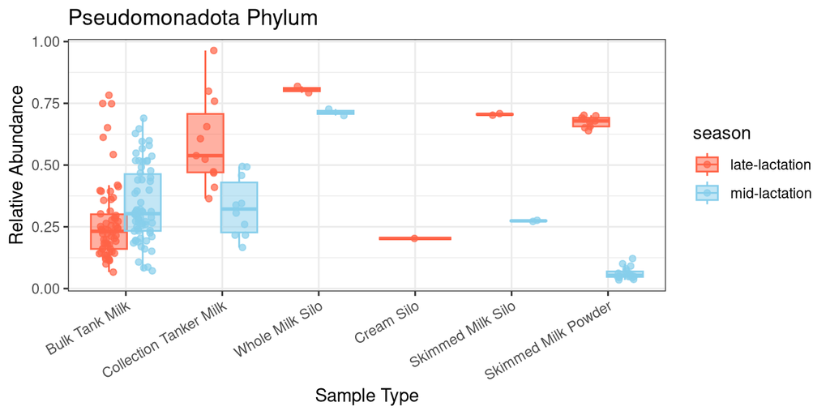

```r
pseudomonadota_phylum <-
  phylum_df_season %>%
  filter(Phylum == "Pseudomonadota") %>%
  ggplot(aes(x = environment_material, y = Abundance,
             fill = season, color = season)) +
  geom_boxplot(position = position_dodge(width = 0.7), alpha = 0.5, outlier.shape = NA) +
  geom_jitter(position = position_jitterdodge(jitter.width = 0.2, dodge.width = 0.7), alpha = 0.7) +
  theme_bw() +
  labs(title = "Pseudomonadota Phylum", x = "Sample Type", y = "Relative Abundance") +
  scale_color_manual(values = c("mid-lactation" = "skyblue", "late-lactation" = "tomato")) +
  scale_fill_manual(values = c("mid-lactation" = "skyblue", "late-lactation" = "tomato")) +
  theme(
    axis.text.x = element_text(angle = 30, hjust = 1, vjust = 1),
    legend.position = "right"
  )

pseudomonadota_phylum
```

Some other fun results for the Skimmed Milk Powder Samples, but this time higher relative abundance in the late-lactation samples. This is nice because it also mirrors what we were seeing in our original stacked phyla bar chart where Pseudomonadota remained dominant in the late-lactation Skimmed Milk Powder samples but not the mid-lactation samples.

## Genus

Now time to follow up with some deeper taxonomic analysis at the genus level.

-**Deinococcota** -Bacteroidota

```r
genus_df_season <-
  scaled_physeq_season %>%
  # Agglomerate all ASV counts within a phylum
  tax_glom(taxrank = "Genus") %>%
  # Calculate the relative abundance!
  transform_sample_counts(function(x) {x/sum(x)}) %>%
  # Create a dataframe from phyloseq object
  psmelt() %>%
  #Filter out Phyla < 1 %
  #dplyr::filter(Abundance > 0.01) %>%
  #Fix the station order
  mutate(environment_material = fct_relevel(environment_material, c(
    "Bulk Tank Milk", "Collection Tanker Milk", "Whole Milk Silo", "Cream Silo", "Skimmed Milk Silo", "Skimmed Milk Powder")))
```

### Deinococcota Genera

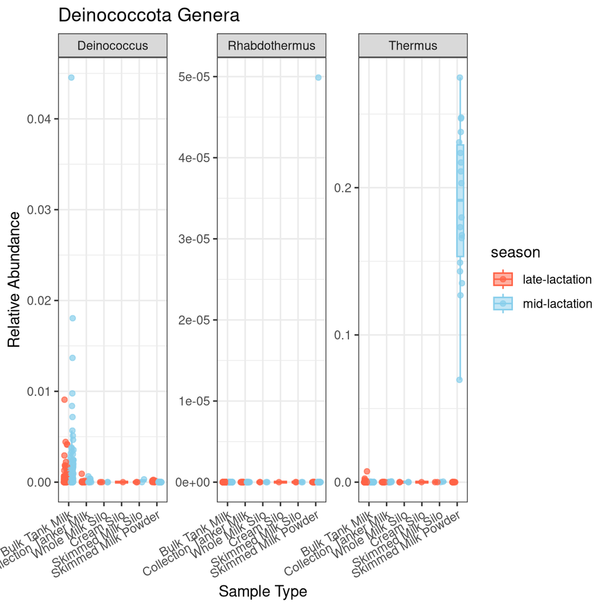

```r
deino_genus <-
  genus_df_season %>%
  filter(Phylum == "Deinococcota") %>%
  ggplot(aes(x = environment_material, y = Abundance,
             fill = season, color = season)) +
  facet_wrap(~Genus, scales = "free_y", nrow = 1) +
  geom_boxplot(position = position_dodge(width = 0.7), alpha = 0.5, outlier.shape = NA) +
  geom_jitter(position = position_jitterdodge(jitter.width = 0.2, dodge.width = 0.7), alpha = 0.7) +
  theme_bw() +
  labs(title = "Deinococcota Genera", x = "Sample Type", y = "Relative Abundance") +
  scale_color_manual(values = c("mid-lactation" = "skyblue", "late-lactation" = "tomato")) +
  scale_fill_manual(values = c("mid-lactation" = "skyblue", "late-lactation" = "tomato")) +
  theme(
    axis.text.x = element_text(angle = 30, hjust = 1, vjust = 1),
    legend.position = "right"
  )

# View
deino_genus
```

Wow - very, very cool!

Super interesting to see how this increase in abundance in Deinococcota in the mid-lactation Skim Milk Powder samples is being driven by only one genus: *Thermus*.

### Bacteroidota Genera

Now, again just out of curiosity I want to do the same thing for Bacteroidota.

```r
#See how many genera in Bacteroidota because I am curious
genus_df_season %>%
  filter(Phylum == "Bacteroidota") %>%
  distinct(Genus) %>%
  nrow()
```

```
## [1] 195
```

```r
#wow there are 195 genera, we simply cannot plot them all!

#instead I will plot the 10 Bacteroidota genera with the highest mena abundance across all samples/seasons

# Find top 10 Bacteroidota genera (highest mean abundance across all seasons/samples)
top10_bacteroidota_genera <- genus_df_season %>%
  filter(Phylum == "Bacteroidota") %>%
  group_by(Genus) %>%
  summarize(mean_abund = mean(Abundance, na.rm = TRUE)) %>%
  arrange(desc(mean_abund)) %>%
  slice_head(n = 10) %>%
  pull(Genus)

# View it!
top10_bacteroidota_genera
```

```
##  [1] "Bacteroides"                 "Chryseobacterium"
##  [3] "Rikenellaceae RC9 gut group" "Alistipes"
##  [5] "Flavobacterium"              "Prevotellaceae UCG-003"
##  [7] "Prevotellaceae UCG-004"      "Xylanibacter"
##  [9] "dgA-11 gut group"            "Fermentimonas"
```

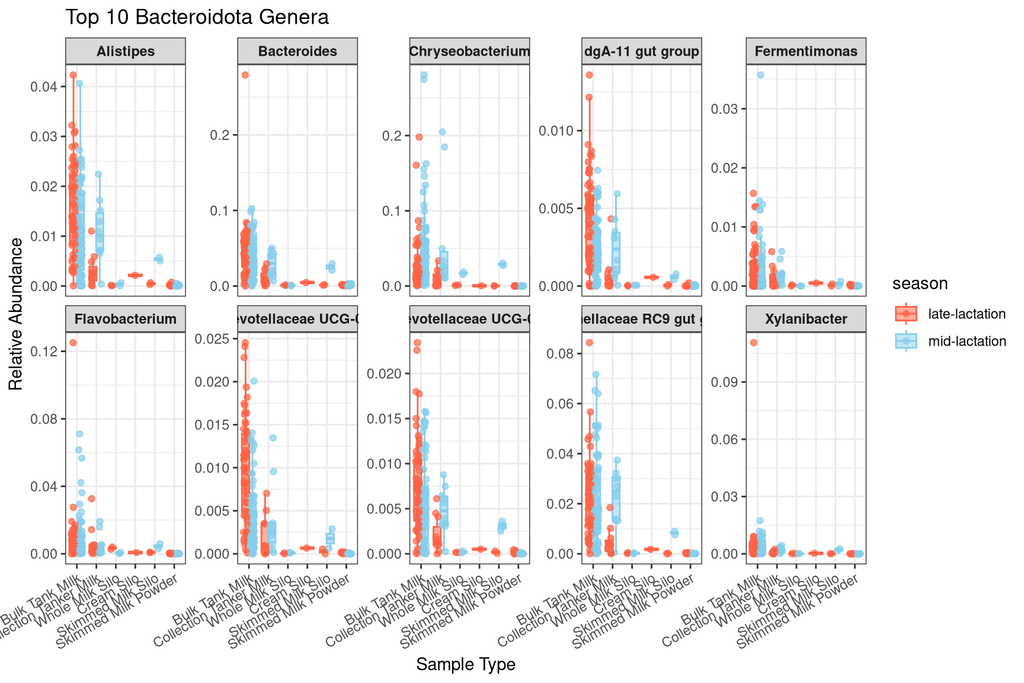

```r
# Now plot only those top 10
bacteroid_genus <-
  genus_df_season %>%
  filter(Phylum == "Bacteroidota", Genus %in% top10_bacteroidota_genera) %>%
  ggplot(aes(x = environment_material, y = Abundance,
             fill = season, color = season)) +
  facet_wrap(~Genus, scales = "free_y", nrow = 2) +
  geom_boxplot(position = position_dodge(width = 0.7), alpha = 0.5, outlier.shape = NA) +
  geom_jitter(position = position_jitterdodge(jitter.width = 0.2, dodge.width = 0.7), alpha = 0.7) +
  theme_bw() +
  labs(title = "Top 10 Bacteroidota Genera", x = "Sample Type", y = "Relative Abundance") +
  scale_color_manual(values = c("mid-lactation" = "skyblue", "late-lactation" = "tomato")) +
  scale_fill_manual(values = c("mid-lactation" = "skyblue", "late-lactation" = "tomato")) +
  theme(
    axis.text.x = element_text(angle = 30, hjust = 1, vjust = 1),
    strip.text = element_text(face = "bold"),
    legend.position = "right"
  )

# View it
bacteroid_genus
```

Just like in my original 07_Composition document, there were way too many genera to be displayed on one plot (it looked like a mess of random numbers when I plotted it). So, I then went and selected the 10 genera with the highest relative abundance.

As a general theme you can see that there is often higher relatiev abundance in the dairy samples that are less processed.

# ASV Level

Now going to explore my data at the ASV level! I am really curious to see what ASVs are contributing to the increase in Thermus for the mid-lactation Skimmed Milk Powder samples.

```r
# Note: The read depth MUST be normalized in some way: scale_reads
ASV_df_season <-
  scaled_physeq_season %>%
  # Prune out ASVs that have fewer than 100 counts!
  ## LOOK AT HOW MANY ARE REMOVED! We scaled to 20090 reads!
  prune_taxa(taxa_sums(.) >= 2009, .) %>%
  # agglomerate at the phylum level
  tax_glom(taxrank = "ASV") %>%
  # Transform counts to relative abundance
  transform_sample_counts(function (x) {x/sum(x)}) %>%
  # Melt to a long format
  psmelt() %>%
  # fix the order of date
  mutate(environment_material = fct_relevel(environment_material, c(
    "Bulk Tank Milk", "Collection Tanker Milk", "Whole Milk Silo", "Cream Silo", "Skimmed Milk Silo", "Skimmed Milk Powder")))

#View
ASV_df_season
```

[output not shown]

[output cut: 26860 more lines]

### Deinococcota ASVs

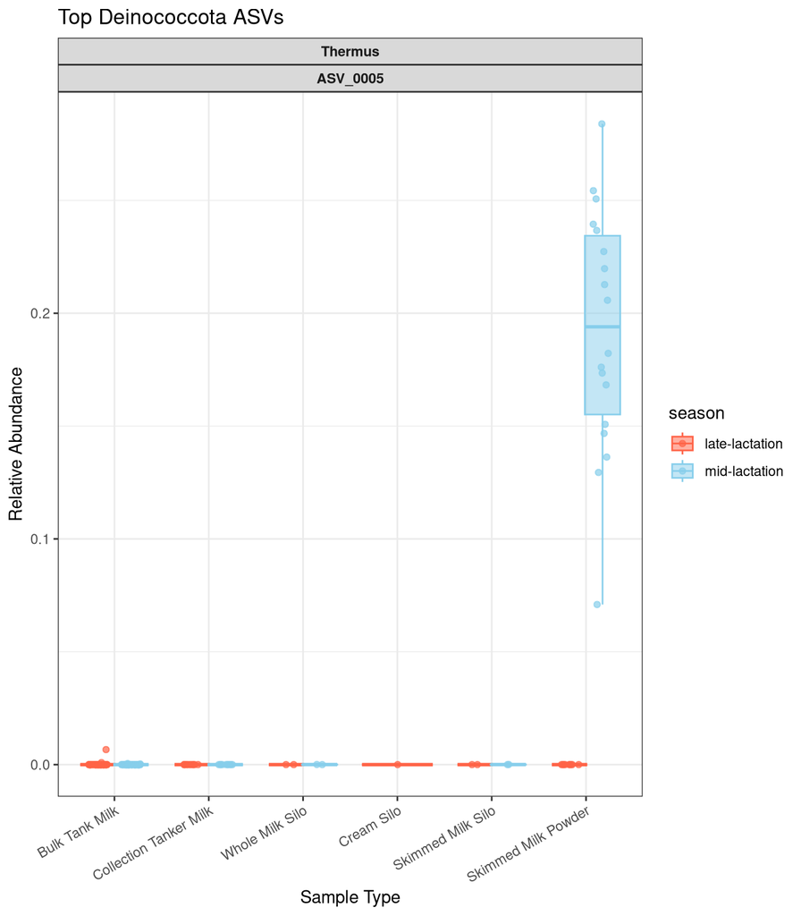

```r
#Calculate top ASVs (mean abundance > 0.005)

top_deino_ASVs <-
  ASV_df_season %>%
  filter(Phylum == "Deinococcota") %>%
  group_by(ASV) %>%
  summarize(mean_Abundance = mean(Abundance, na.rm = TRUE)) %>%
  filter(mean_Abundance > 0.005) %>%
  pull(ASV)

#Plot
deino_asv_sample_type <-
  ASV_df_season %>%
  filter(ASV %in% top_deino_ASVs) %>%
  ggplot(aes(x = environment_material, y = Abundance,
             fill = season, color = season)) +
  facet_wrap(Genus~ASV, scales = "free_y", nrow = 2) +
  geom_boxplot(position = position_dodge(width = 0.7), alpha = 0.5, outlier.shape = NA) +
  geom_jitter(position = position_jitterdodge(jitter.width = 0.2, dodge.width = 0.7), alpha = 0.7) +
  theme_bw() +
  labs(title = "Top Deinococcota ASVs", x = "Sample Type", y = "Relative Abundance") +
  scale_color_manual(values = c("mid-lactation" = "skyblue", "late-lactation" = "tomato")) +
  scale_fill_manual(values = c("mid-lactation" = "skyblue", "late-lactation" = "tomato")) +
  theme(
    axis.text.x = element_text(angle = 30, hjust = 1, vjust = 1),
    strip.text = element_text(face = "bold"),
    legend.position = "right"
  )

# View it
deino_asv_sample_type
```

Again, super cool stuff - only one ASV, ASV_005, is driving this change in relative abundance ONLY in the mid-lactation Skim Milk samples.

Seeing this sort of reinforces the ideas from our ordination and stacked bar plot that season can be a significant influence, and that the microbial composition differs across skim milk powder samples collected in different seasons.

I blasted ASV_005 and it turns out to be a match for *Thermus thermophilus* (which is a thermophile if you can’t tell by the name haha)!

Note that if I had more time to complete this project I would carry out the same analysis I did above with Geobacillus. If you recall, in 07_Composition, we looked at the relative abundance of Geobacillus across the different sample types. Geobacillus was another thermophilic genus where we saw the large increase in relaitve abundance in skim milk powder samples, but there was very evident bimodal distribution.

Below I have plotted the Bacteroidota ASVs, similar to how I’ve done above. Out of curiousity (and to compare ot my initial analysis where I did not look at season), I also identified and plotted the 10 most abundant ASVs by season, although I didn’t really take my analysis any further.

### Bacteroidota ASVs

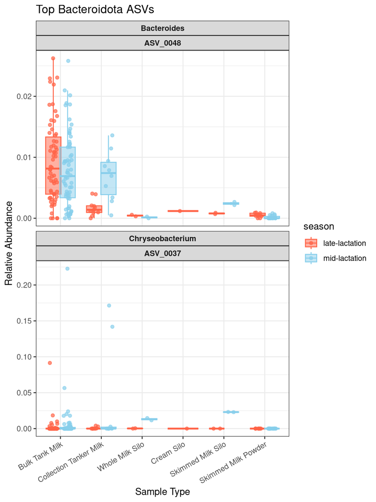

```r
#Calculate top ASVs (mean abundance > 0.005)

top_bacteroid_ASVs <-
  ASV_df_season %>%
  filter(Phylum == "Bacteroidota") %>%
  group_by(ASV) %>%
  summarize(mean_Abundance = mean(Abundance, na.rm = TRUE)) %>%
  filter(mean_Abundance > 0.005) %>%
  pull(ASV)

#Plot
bacteroid_asv_sample_type <-
  ASV_df_season %>%
  filter(ASV %in% top_bacteroid_ASVs) %>%
  ggplot(aes(x = environment_material, y = Abundance,
             fill = season, color = season)) +
  facet_wrap(Genus~ASV, scales = "free_y", nrow = 2) +
  geom_boxplot(position = position_dodge(width = 0.7), alpha = 0.5, outlier.shape = NA) +
  geom_jitter(position = position_jitterdodge(jitter.width = 0.2, dodge.width = 0.7), alpha = 0.7) +
  theme_bw() +
  labs(title = "Top Bacteroidota ASVs", x = "Sample Type", y = "Relative Abundance") +
  scale_color_manual(values = c("mid-lactation" = "skyblue", "late-lactation" = "tomato")) +
  scale_fill_manual(values = c("mid-lactation" = "skyblue", "late-lactation" = "tomato")) +
  theme(
    axis.text.x = element_text(angle = 30, hjust = 1, vjust = 1),
    strip.text = element_text(face = "bold"),
    legend.position = "right"
  )

# View it
bacteroid_asv_sample_type
```

### Identifying the 10 most abundant ASVs:

```r
#identify my top ten ASVs total (all samples)
top_asvs_total <- names(sort(taxa_sums(scaled_physeq_season), decreasing = TRUE))[1:10]

#View my top 10 ASVs
top_asvs_total
```

```
##  [1] "ASV_0003" "ASV_0001" "ASV_0002" "ASV_0004" "ASV_0007" "ASV_0006"
##  [7] "ASV_0005" "ASV_0009" "ASV_0008" "ASV_0011"
```

```r
# Mid-lactation
top_asvs_mid <-
  scaled_physeq_season %>%
  # Filter for mid-lactation samples
  subset_samples(season == "mid-lactation") %>%
   # Get the abundance for each ASV
  taxa_sums() %>%
  sort(decreasing = TRUE) %>%
  names() %>%
  # Get the top 10
  .[1:10]

# View the top 10 ASVs for mid-lactation
top_asvs_mid
```

```
##  [1] "ASV_0001" "ASV_0003" "ASV_0005" "ASV_0008" "ASV_0002" "ASV_0014"
##  [7] "ASV_0009" "ASV_0006" "ASV_0016" "ASV_0012"
```

```r
# Late-lactation
top_asvs_late <-
  scaled_physeq_season %>%
  # Filter for late-lactation samples
  subset_samples(season == "late-lactation") %>%
   # Get the abundance for each ASV
  taxa_sums() %>%
  sort(decreasing = TRUE) %>%
  names() %>%
  # Get the top 10
  .[1:10]

# View the top 10 ASVs for mid-lactation
top_asvs_late
```

```
##  [1] "ASV_0002" "ASV_0003" "ASV_0007" "ASV_0004" "ASV_0006" "ASV_0018"
##  [7] "ASV_0011" "ASV_0013" "ASV_0017" "ASV_0010"
```

### Plotting most abundant ASVs

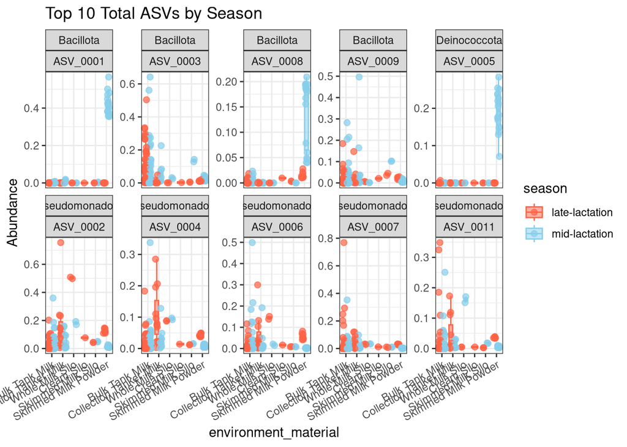

```r
#Plot top 10 abundant ASVs across all samples

ASV_df_season %>%
  filter(ASV %in% top_asvs_total) %>%
  ggplot(aes(x = environment_material, y = Abundance,
             fill = season, color = season)) +  # Map 'season' to fill and color
  facet_wrap(Phylum ~ ASV, scales = "free_y", nrow = 2) +  # Facet by Phylum and ASV
  geom_boxplot(alpha = 0.5, outlier.shape = NA) +  # Add boxplot
  geom_point(position = position_jitterdodge(jitter.width = 0.2, dodge.width = 0.8),
             alpha = 0.7, size = 2) +  # Adjust jitter for separation
  theme_bw() +
  labs(title = "Top 10 Total ASVs by Season") +
  scale_color_manual(values = c("mid-lactation" = "skyblue", "late-lactation" = "tomato")) +
  scale_fill_manual(values = c("mid-lactation" = "skyblue", "late-lactation" = "tomato")) +
  theme(axis.text.x = element_text(angle = 30, hjust = 1, vjust = 1))
```

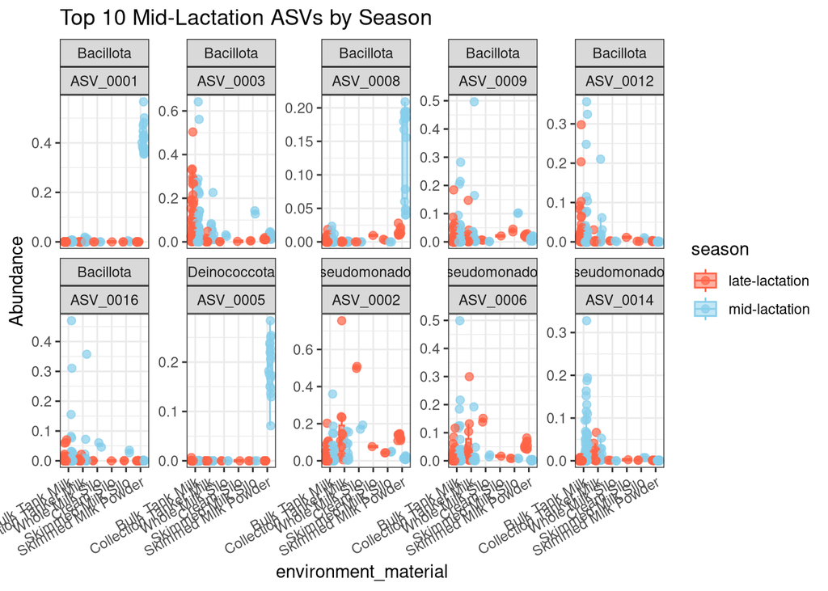

```r
#Plot top ten most abundant ASVs in mid-lactation samples

ASV_df_season %>%
  filter(ASV %in% top_asvs_mid) %>%
  ggplot(aes(x = environment_material, y = Abundance,
             fill = season, color = season)) +  # Map 'season' to fill and color
  facet_wrap(Phylum ~ ASV, scales = "free_y", nrow = 2) +  # Facet by Phylum and ASV
  geom_boxplot(alpha = 0.5, outlier.shape = NA) +  # Add boxplot
  geom_point(position = position_jitterdodge(jitter.width = 0.2, dodge.width = 0.8),
             alpha = 0.7, size = 2) +  # Adjust jitter for separation
  theme_bw() +
  labs(title = "Top 10 Mid-Lactation ASVs by Season") +
  scale_color_manual(values = c("mid-lactation" = "skyblue", "late-lactation" = "tomato")) +
  scale_fill_manual(values = c("mid-lactation" = "skyblue", "late-lactation" = "tomato")) +
  theme(axis.text.x = element_text(angle = 30, hjust = 1, vjust = 1))
```

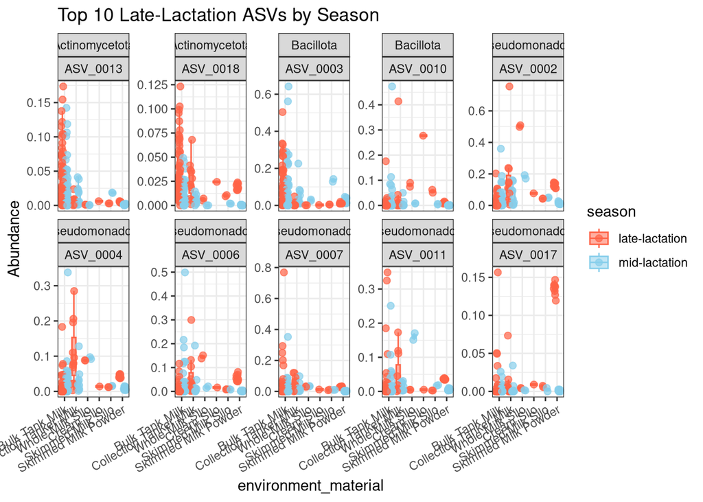

```r
#Plot top ten most abundant ASVs in late-lactation samples

ASV_df_season %>%
  filter(ASV %in% top_asvs_late) %>%
  ggplot(aes(x = environment_material, y = Abundance,
             fill = season, color = season)) +  # Map 'season' to fill and color
  facet_wrap(Phylum ~ ASV, scales = "free_y", nrow = 2) +  # Facet by Phylum and ASV
  geom_boxplot(alpha = 0.5, outlier.shape = NA) +  # Add boxplot
  geom_point(position = position_jitterdodge(jitter.width = 0.2, dodge.width = 0.8),
             alpha = 0.7, size = 2) +  # Adjust jitter for separation
  theme_bw() +
  labs(title = "Top 10 Late-Lactation ASVs by Season") +
  scale_color_manual(values = c("mid-lactation" = "skyblue", "late-lactation" = "tomato")) +
  scale_fill_manual(values = c("mid-lactation" = "skyblue", "late-lactation" = "tomato")) +
  theme(axis.text.x = element_text(angle = 30, hjust = 1, vjust = 1))
```

# Final Project Reflections

It is really cool to see how far I’ve come over the course of the semester. I think by looking at my first analysis documents to my later ones, you can tell that I have gotten better at writing analysis, including notes in my code, and organizing/structuring my analysis documents. I’ve also gotten so much more comfortable using R.

Although I’ve made great progress, I didn’t get as far as I’d like to have gotten on this project. If I had more time I would like to investigate more thermophilic genera and compare their relative abundances in Skim Milk Powder samples (so I can accept/reject the hypothesis I made in this document about Skim Milk Powder samples being enriched for thermophilic bacteria). I would have liked to add stats to a lot more of my plots/results.

I also would have loved to explore how Cronobacter shows up in these dairy sample microbial communities. The reason I originally chose this paper is because I started a project during my Wiedmann Lab rotation that focused on looking at environmental prevalence of Cronobacter. Cronobacter is Gram negative bacteria that often creates fatal/severe infections in infants. It also has the unique ability to survive in powdered infant formula. So, if not eradicated in the processing pipeline, or contaminated in this processing pipeline, there can be really severe and really heartbreaking consequences. And when I was looking into microbial community studies within milk powder products, the literature was LACKING, and I really wished there was more information.

Anywho, I’m happy with the work I was able to produce - I really enjoyed learning more about the bioninformatic pipeline that makes community analysis possible! Thanks again!

# Final info for Reproducibility

## Check Render Time

```r
# Take the time now that we are at the end of the script
end_time <- Sys.time()
end_time
```

```
## [1] "2025-05-02 16:28:15 EDT"
```

```r
# Echo the elapsed time
elapsed_time <- round((end_time - start_time), 3)
elapsed_time
```

```
## Time difference of 5.882 mins
```